# Bruhn_A21_2

## A21.13 問題

1. Fig. A21.66 は、示されているように荷重を受け、4枚のウェブパネルを持つ片持ち梁を示している。4つのウェブパネルのそれぞれにおけるせん断流を求めよ。各垂直ウェブ補強材、および水平補強材 $be$ の軸荷重図を描け。ウェブせん断流から得られる梁フランジ部材の軸荷重図をプロットせよ。

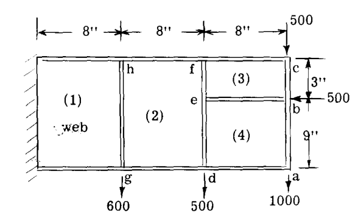

Fig. A21.66

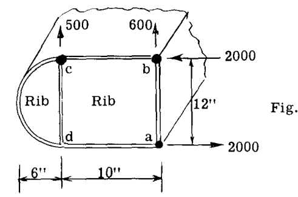

Fig. A21.67

3. Fig. A21.68 は、3本のストリンガーからなる単一セル翼梁を示している。示されているように集中荷重を分配するためにリブが挿入されている。
1. リブウェブパネル (1)、(2)、および (3) におけるせん断流を求めよ。
2. 断面 $dc$ および $ab$ におけるリブフランジ荷重を求めよ。

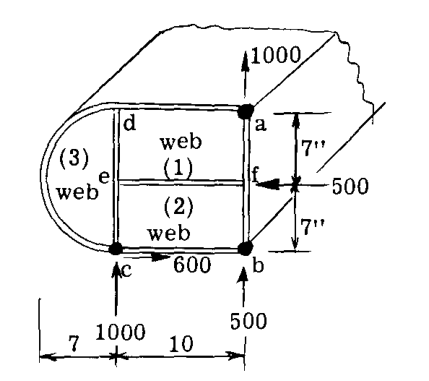

Fig. A21.68

4. Fig. A21.69 は、2本のストリンガー、2セルの翼梁を示している。梁構造に $1000\text{ lb.}$ の荷重を伝達するためにリブが挿入されている。線 $ab$ に隣接する各セルのリブウェブにおけるせん断流を求めよ。また、点 (a) および (b) に隣接するリブフランジ荷重を求めよ。

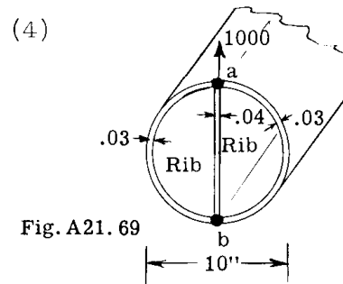

Fig. A21.69

5. Fig. A21.70 は、4本のストリンガーからなる片持ち単一セル翼梁の3つのベイを示している。ベイ (2) の下部外板は除去されている。外翼荷重が以下の通りであるとき、すべてのベイにおけるせん断流、およびリブ (A) と (B) 上の境界荷重を求めよ。 $T = 56000\text{ in.lb.}, P_1 = 0, P_2 = 0, P_3 = 2000\text{ lb.}, P_4 = 2000\text{ lb.}, P_5 = 0$ 。

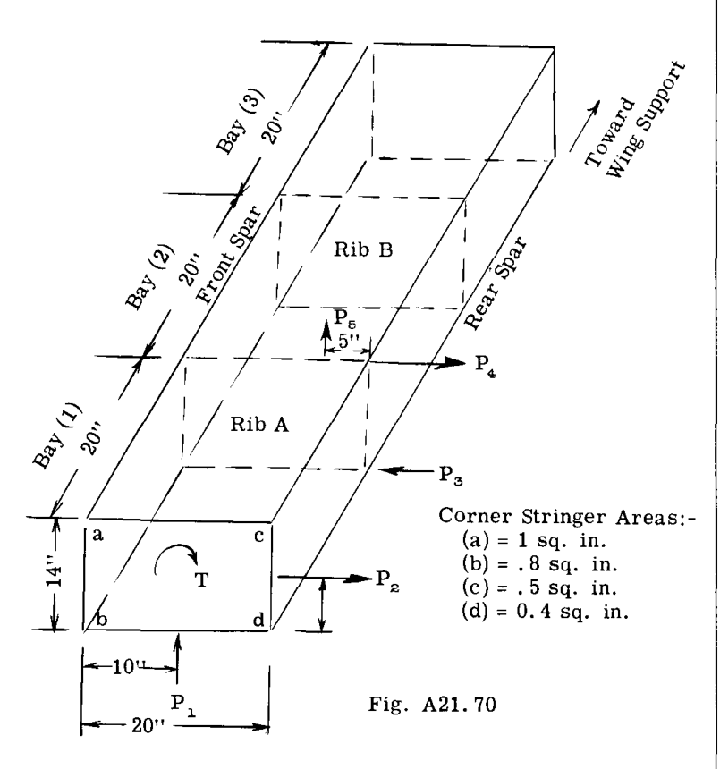

Fig. A21.70

6. 問題 (5) と同様であるが、下部外板の代わりにベイ (2) の上部外板が除去されている場合について求めよ。
7. 問題 (5) と同様であるが、以下の外荷重を受ける場合について求めよ。

$$T = 56000\text{ in.lb.}, P_1 = 5000\text{ lb.}, P_2 = 2000\text{ lb.}, P_3 = P_4 = 0\text{、および } P_5 = 1000\text{ lb.}$$

8. 問題 (7) と同様であるが、下部外板の代わりに上部外板が除去されている場合について求めよ。
9. 問題 (5) と同様であるが、下部外板の代わりに後方スパーウェブが除去されている場合について求めよ。
10. 問題 (7) と同様であるが、下部外板の代わりに後方スパーウェブが除去されている場合について求めよ。
11. Fig. A21.71 において、外部バルクヘッド荷重 $P_1$ および $P_2$ はそれぞれ $4000\text{ lb.}$ に等しく、 $P_3$ はゼロに等しい。胴体ストリンガー材料は、断面積がそれぞれ $.25\text{ sq. in.}$ の4つのオメガセクションで構成されている。上記の荷重のバランスをとる際に、バルクヘッド上の外板抵抗力を決定せよ。この問題では有効な外板を無視せよ。

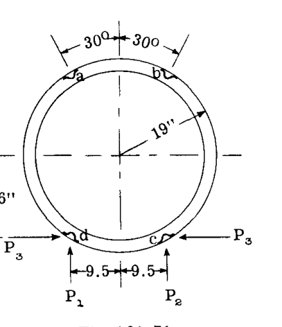

Fig. A21.71

12. 問題 (11) と同様であるが、 $P_1 = 4000$ および $P_2 = 6000$ とした場合について求めよ。
13. 問題 (12) と同様であるが、 $P_3 = 3000\text{ lb.}$ を追加した場合について求めよ。
14. 水着陸状態において、Fig. A21.72 のハルフレームは $2000\text{ lb./in.}$ の法線底部圧力を受ける。バルブアングルストリンガーの面積はそれぞれ $.11\text{ sq. in.}$ で、深さは $7/8\text{ in.}$ である。 Z ストリンガーの面積はそれぞれ $.18\text{ sq. in.}$ で、深さは $1.5\text{ in.}$ である。ストリンガー a, b, c, d, e の面積はそれぞれ $.20\text{ sq. in.}$ である。有効外板を無視して、底部の水圧とバランスをとるフレーム上の外板抵抗力を決定せよ。

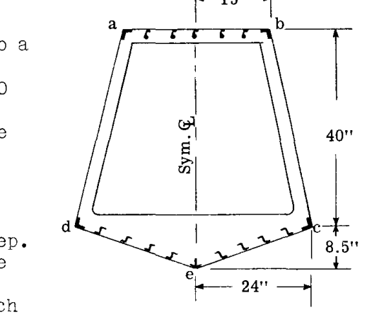

Fig. A21.72

15. 問題 (14) と同様であるが、水圧がフレーム底部の一方の側のみに作用していると仮定して求めよ。